# Module 2

Hunter Ratliff, @HunterRatliff1

March 11, 2016

# Abstract

Fetal Alcohol Spectrum Disorder (FASD) describes the range of phenotypic defects resulting from ethanol exposure during embryonic development. FASD is a product of complex interactions between genetic predispositions and the environment, often resulting in a spectrum of altered neurological and facial defects. Here we examined the effects exposure to 1% ethanol solution had on the development of facial bones in two mutant strains of zebrafish (*131.5* and *Au15*). Specifically, we examined the length of the palatoquadrate (pq), ceratohyal (ch), and Mekel’s (m) bones, as well as the widths of the arches that they form. Our results found that these bones saw a statistically significant increase in bone length if the Au15 mutation was present, or if embryos were exposed to ethanol. These findings indicate an interaction between the environment and genetic mutations in the craniofacial development of zebrafish embryos.

# Method

## Embryos and treatment

Embryos were provided by the [Eberhart lab](http://www.sbs.utexas.edu/eberhart/), and all embryos were raised and cared for using established IACUC protocols approved by the University of Texas at Austin. Both mutant strains of zebrafish embryos (*131.5* and *Au15*) were treated with `1% EtOH` at 24 hpf, and embryos were allowed to develop for 4 days at 28.5°C. Embryos were then fixed in `2% PFA in PBS`, and washed 1 x 10 min with `100 mM Tris pH 7.5 / 10 mM \(MgCl_2\)`.

## Staining

Embryos were stained for cartilage (using Alcian blue stain) for one day, and consequently destained with a series of `80%`, `50%`, and `25%` `EthOH / 100 mM Tris pH 7.5 / 10 mM \(MgCl_2\)` washes (3 x 5 min). Afterwards, embryos were bleached with `3% \(H_2O_2\) / 0.5% KOH` for 1 x 10 min and washed for 2 x 10 min with `25% glycerol / 0.1% KOH`. Finally, embryos were stained for bone (using Alcian red stain) for 30 min, destained with `50% glycerol / 0.1% KOH`, and imaged on stereoscopes.

# Results

## Linear Regression of Bone Length

```
##   r.squared adj.r.squared    sigma statistic      p.value df    logLik
## 1 0.8197119     0.8030185 29.74064  49.10411 6.911307e-19  6 -285.5264
##        AIC      BIC deviance df.residual
## 1 585.0527 599.7132 47763.32          54
```

```
##            term    estimate  std.error  statistic      p.value
## 1   (Intercept) 222.2787129 20.8803638 10.6453467 7.133932e-15
## 2         Width   0.5212174  0.1204864  4.3259431 6.596727e-05
## 3      Segmentm -49.1609254 11.5414552 -4.2595084 8.243472e-05
## 4     Segmentpq  -6.5128739 11.4526136 -0.5686801 5.719308e-01
## 5 TreatmentEtOH  44.1116859  8.1852642  5.3891585 1.591814e-06
## 6      GeneAu15  26.2083006 12.1514995  2.1567956 3.549136e-02
```

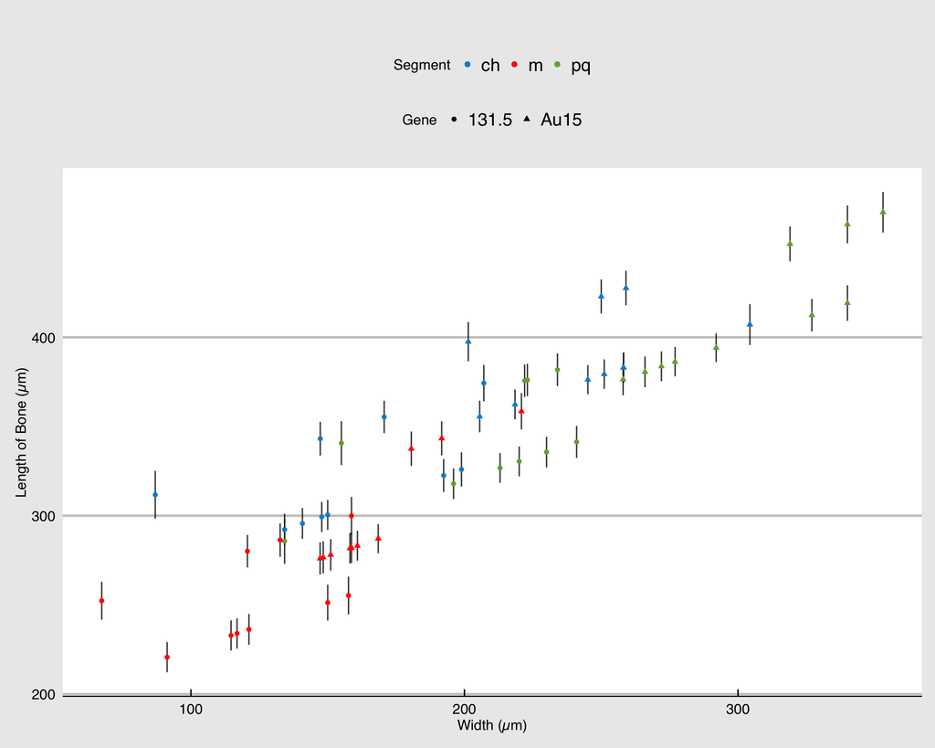

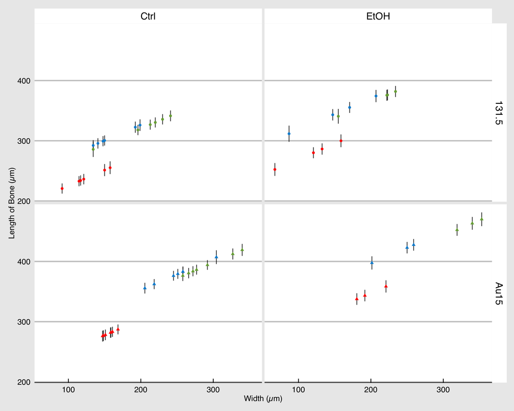

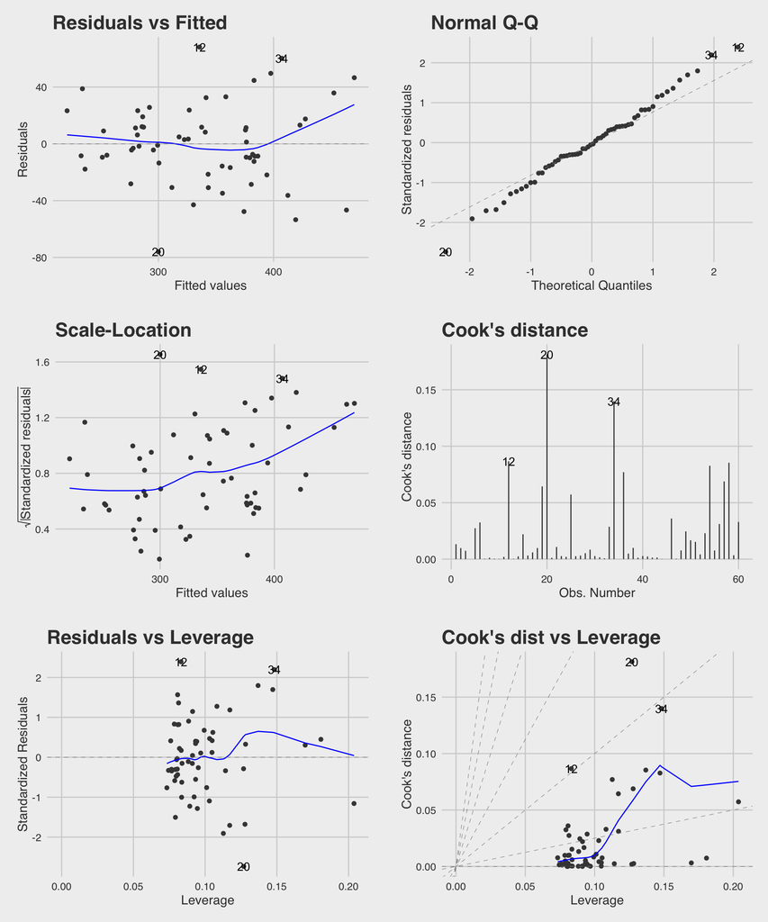

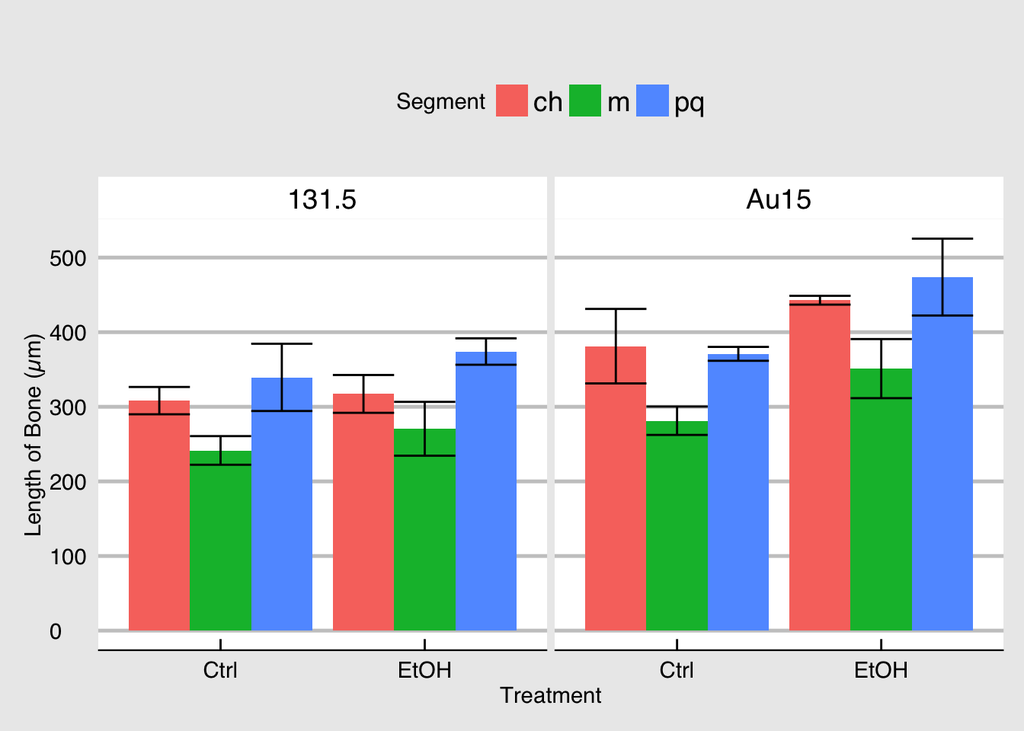

```r
df %>% group_by(Gene, Segment, Treatment) %>% summarise(m = mean(Length), sd = sd(Length)) %>%
  ggplot(aes(x=Treatment, fill=Segment)) +
  geom_bar(aes(y=m), stat="identity", position = "dodge") + geom_errorbar(aes(ymax=m+sd, ymin=m-sd), position = "dodge") +
  scale_color_fivethirtyeight() +
  labs(y="Length of Bone (µm)", x="Treatment") +
  theme_economist_white() + theme(axis.title=element_text()) + facet_wrap("Gene")
```